# LCL co-access vs background CREs: footprints, length, class

# Features of co-accessible CREs

This analysis describes whether co-accessible CREs are longer and have higher footprint density than background CREs, and compares their CRE-class composition

CREs come from `cre_summary/inputs/eligible_cres.tsv.gz` (eligible autosomal CREs with >= 10 open, informative fibers) and are split into co-access CREs (in >= 1 donor-adjusted co-access pair) and background CREs (the remaining eligible CREs)

- Each counted fiber must individually cover the entire CRE, have its own FIRE element covering >= 50% of the CRE after accounting for deletions –> all reads meet this criteria counts as denominator

```bash
cd /project/spott/cshan/fiber-seq/code/co-accessibility/LCL/cre_summary
a=$(sbatch --parsable --partition=caslake --qos=caslake --mem=48G --array=1-31%6 LCL_tf_cooccupancy.sh footprints)
sbatch --partition=caslake --qos=caslake --mem=48G --dependency=afterok:$a LCL_tf_cooccupancy.sh footprints_combine
```

`/project/spott/cshan/fiber-seq/code/co-accessibility/LCL/cre_summary/count_cre_footprints.R`

- measures how often, and where, TF sized footprints occur inside each CRE
- recurrent footprints a stretch of bases inside a CRE where at least 15% of the CRE’s informative fibers carry a footprint at the same place, with at least 5 fibers at its strongest base

```r
library(data.table)
library(ggplot2)
setDTthreads(1L)
root <- params$root
dest <- params$dest
out <- file.path(dest,'cre_summary')
inputs <- file.path(out,'inputs')
required <- c(file.path(root,'cre_footprint_summary.tsv.gz'),
  file.path(inputs,'eligible_cres.tsv.gz'))
missing <- required[!file.exists(required)]
if(length(missing)) stop('Missing ',paste(missing,collapse=', '),
  '. Restore eligible_cres.tsv.gz under cre_summary/inputs if missing; ',
  'run the footprints jobs above if cre_footprint_summary.tsv.gz is missing.')
for(d in c('tables','plots')) dir.create(file.path(out,d),recursive=TRUE,showWarnings=FALSE)
source('/project/spott/cshan/fiber-seq/code/parsing_functions/plotting_functions.r')
write_tsv <- function(x,name) fwrite(x,file.path(out,'tables',name),sep='\t',na='NA')
save_plot <- function(p,name,w=8,h=5) save_figure(p,file.path(out,'plots',name),width=w,height=h)
set_cols <- c(background='#3274a1','co-access'='#d95f02')
```

Combine eligible CREs and footprints

eligible CRE and footprint summary

| Column | Meaning |
| --- | --- |
| `n_footprints` | Total qualifying footprint occurrences overlapping the CRE across informative fibers |
| `footprint_bp` | Total footprint-covered bases within the CRE, summed across fibers; overlapping footprints on the same fiber count once per base |
| `fibers_with_fp` | Number of informative fibers with at least one qualifying footprint overlapping the CRE |
| `footprints_per_fiber` | `n_footprints / n_informative` |
| `pct_bases_footprinted` | `100 × footprint_bp / (n_informative × CRE length)` |
| `peak_pct` | Highest percentage of informative fibers footprinted at any single base in the CRE |
| `n_positions` | Number of recurrent footprint positions in the CRE |

```r
# load CRE and footprint summary
cre <- fread(file.path(inputs,'eligible_cres.tsv.gz'),select=c('CRE_ID','chrom','start','end','CRE_class','set','n_informative'))
fp <- fread(file.path(root,'cre_footprint_summary.tsv.gz'))
cre <- merge(cre,fp[,.(CRE_ID,fp_informative=n_informative,n_footprints,footprint_bp,fibers_with_fp,
  footprints_per_fiber,pct_bases_footprinted,peak_pct,n_positions)],by='CRE_ID',all.x=TRUE)

stopifnot(!anyNA(cre$fp_informative),identical(cre$fp_informative,cre$n_informative))
cre[,`:=`(length=end-start,set=factor(set,levels=c('co-access','background')),fp_informative=NULL)]
cre[,footprints_per_fiber_per_100bp:=100*footprints_per_fiber/length]
cre[,.N,by=set]
```

```
##           set     N
##        <fctr> <int>
## 1: background 72582
## 2:  co-access  5557
```

```r
head(print(cre))
```

```
## Key: <CRE_ID>
##                                CRE_ID  chrom     start       end CRE_class
##                                <char> <char>     <int>     <int>    <char>
##     1: EH38D0076589.EH38E0102310.dELS   chr1  90721495  90721738      dELS
##     2: EH38D0102812.EH38E0114249.dELS   chr1 150164854 150165136      dELS
##     3: EH38D0113114.EH38E0118842.dELS   chr1 161762075 161762338      dELS
##     4: EH38D0190655.EH38E0158249.dELS  chr10  12353483  12353774      dELS
##     5: EH38D0260385.EH38E1497987.dELS  chr10 108568438 108568675      dELS
##    ---
## 78135: EH38F0085897.EH38E4455478.pELS   chr7 150049107 150049299      pELS
## 78136: EH38F0086015.EH38E4071211.pELS  chr12  89707430  89707580      pELS
## 78137: EH38F0086331.EH38E4450875.dELS   chr7 129146983 129147227      dELS
## 78138:   EH38F0086547.EH38E4461869.TF   chr8  17925546  17925746        TF
## 78139: EH38F0086571.EH38E4064422.pELS  chr12  54281357  54281507      pELS
##               set n_informative n_footprints footprint_bp fibers_with_fp
```

[output cut: 38 more lines]

```
## Key: <CRE_ID>
##                            CRE_ID  chrom     start       end CRE_class
##                            <char> <char>     <int>     <int>    <char>
## 1: EH38D0076589.EH38E0102310.dELS   chr1  90721495  90721738      dELS
## 2: EH38D0102812.EH38E0114249.dELS   chr1 150164854 150165136      dELS
## 3: EH38D0113114.EH38E0118842.dELS   chr1 161762075 161762338      dELS
## 4: EH38D0190655.EH38E0158249.dELS  chr10  12353483  12353774      dELS
## 5: EH38D0260385.EH38E1497987.dELS  chr10 108568438 108568675      dELS
## 6: EH38D0371750.EH38E0243977.dELS  chr11 121421567 121421842      dELS
##           set n_informative n_footprints footprint_bp fibers_with_fp
##        <fctr>         <int>        <int>        <int>          <int>
## 1: background           239          306         7886            202
## 2: background            41           35          718             25
## 3: background           131          283         6641            126
## 4:  co-access            85          109         1794             67
```

[output cut: 18 more lines]

## Do co-access CREs have more footprints?

Footprint density is the number of footprints per informative fiber divided by CRE length and multiplied by 100. The percentage of bases footprinted is averaged over informative fibers, using the union of footprint-covered bases within each fiber

A recurrent position is a contiguous stretch of CRE bases footprinted on >= 15% of informative fibers, with >= 5 fibers at its peak. Peak footprint frequency is the maximum percentage of informative fibers footprinted at any base in the CRE

1. Footprints per informative fiber: average number of footprints touching the CRE on each informative fiber. A footprint counts if it shares at least one base with the CRE
2. Footprints per informative fiber per 100 bp: measures footprint density
3. % of CRE bases footprinted. Of all the CRE bases on all informative fibers, this is the percentage covered by a footprint. If one fiber has two overlapping footprints, the shared bases count once. It shows how much of the element is protected on a typical open molecule: low values mean mostly bare, accessible DNA, and high values mean a densely bound element.
4. Recurrent footprint positions per CRE: counts the stretches in the CRE where at least 15% of informative fibers have a footprint at the same bases, with at least 5 fibers at the strongest bas
5. Peak footprint frequency (% of informative fibers): percentage of informative fibers footprinted at the CRE’s single most footprinted base

```r
metrics <- c(footprints_per_fiber='Footprints per informative fiber',
  footprints_per_fiber_per_100bp='Footprints per informative fiber per 100 bp',
  pct_bases_footprinted='% of CRE bases footprinted',
  n_positions='Recurrent footprint positions per CRE',peak_pct='Peak footprint frequency (% of informative fibers)')
describe <- function(d,by_cols) {
  ans <- d[,.(n_CREs=.N),by=by_cols]

  for(m in names(metrics)) ans <- merge(ans,d[,setNames(list(as.numeric(median(get(m))),mean(get(m))),
    paste0(m,c('_median','_mean'))),by=by_cols],by=by_cols)
  ans
}
t1 <- describe(cre,'set')
t1_class <- describe(cre,c('CRE_class','set'))[order(CRE_class,set)]
write_tsv(t1,'footprints_by_set.tsv');write_tsv(t1_class,'footprints_by_set_and_class.tsv')
knitr::kable(t1,digits=2)
```

| set | n_CREs | footprints_per_fiber_median | footprints_per_fiber_mean | footprints_per_fiber_per_100bp_median | footprints_per_fiber_per_100bp_mean | pct_bases_footprinted_median | pct_bases_footprinted_mean | n_positions_median | n_positions_mean | peak_pct_median | peak_pct_mean |
| --- | --- | --- | --- | --- | --- | --- | --- | --- | --- | --- | --- |
| co-access | 5557 | 1.29 | 1.33 | 0.45 | 0.46 | 8.63 | 9.12 | 3 | 3.45 | 38.89 | 40.43 |
| background | 72582 | 0.90 | 0.98 | 0.33 | 0.36 | 6.64 | 7.40 | 2 | 2.30 | 30.97 | 34.17 |

```r
knitr::kable(t1_class,digits=2)
```

| CRE_class | set | n_CREs | footprints_per_fiber_median | footprints_per_fiber_mean | footprints_per_fiber_per_100bp_median | footprints_per_fiber_per_100bp_mean | pct_bases_footprinted_median | pct_bases_footprinted_mean | n_positions_median | n_positions_mean | peak_pct_median | peak_pct_mean |
| --- | --- | --- | --- | --- | --- | --- | --- | --- | --- | --- | --- | --- |
| CA | co-access | 21 | 1.30 | 1.45 | 0.52 | 0.54 | 10.52 | 10.54 | 4 | 4.05 | 40.48 | 44.14 |
| CA | background | 271 | 1.25 | 1.25 | 0.48 | 0.50 | 9.20 | 9.66 | 3 | 3.01 | 41.18 | 42.65 |
| CA-CTCF | co-access | 35 | 1.25 | 1.30 | 0.46 | 0.51 | 9.22 | 10.14 | 3 | 3.49 | 44.50 | 43.74 |
| CA-CTCF | background | 1067 | 1.08 | 1.12 | 0.41 | 0.44 | 8.65 | 9.16 | 3 | 2.72 | 42.29 | 43.29 |
| CA-H3K4me3 | co-access | 36 | 1.13 | 1.20 | 0.46 | 0.47 | 8.51 | 8.96 | 3 | 3.31 | 34.26 | 39.72 |
| CA-H3K4me3 | background | 558 | 1.15 | 1.17 | 0.42 | 0.44 | 9.20 | 9.51 | 3 | 2.78 | 43.87 | 44.75 |
| CA-TF | co-access | 21 | 1.56 | 1.63 | 0.57 | 0.58 | 11.47 | 11.18 | 5 | 4.71 | 50.00 | 49.96 |
| CA-TF | background | 164 | 1.44 | 1.45 | 0.50 | 0.52 | 10.12 | 10.16 | 3 | 3.52 | 46.21 | 46.78 |
| PLS | co-access | 794 | 0.96 | 1.06 | 0.31 | 0.34 | 6.36 | 7.01 | 2 | 2.55 | 31.29 | 34.14 |
| PLS | background | 15071 | 0.69 | 0.78 | 0.24 | 0.26 | 5.11 | 5.74 | 1 | 1.71 | 23.53 | 27.69 |
| TF | co-access | 17 | 1.66 | 1.53 | 0.68 | 0.62 | 12.22 | 12.47 | 3 | 3.59 | 48.94 | 51.62 |
| TF | background | 136 | 1.10 | 1.21 | 0.43 | 0.45 | 8.39 | 9.14 | 2 | 2.71 | 39.41 | 42.07 |
| dELS | co-access | 2932 | 1.44 | 1.46 | 0.50 | 0.52 | 9.56 | 9.99 | 4 | 3.86 | 42.47 | 43.75 |
| dELS | background | 27423 | 1.16 | 1.21 | 0.42 | 0.44 | 8.27 | 8.81 | 3 | 2.96 | 38.94 | 40.63 |
| pELS | co-access | 1701 | 1.14 | 1.21 | 0.40 | 0.43 | 7.94 | 8.52 | 3 | 3.14 | 35.35 | 37.32 |
| pELS | background | 27892 | 0.74 | 0.85 | 0.29 | 0.33 | 5.96 | 6.74 | 1 | 1.93 | 26.67 | 30.58 |

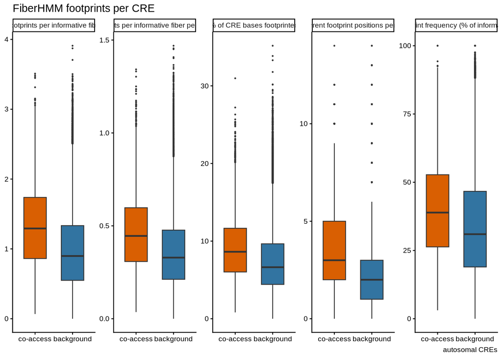

```r
long <- melt(cre[,c(list(set=set),lapply(.SD,as.numeric)),.SDcols=names(metrics)],id.vars='set',variable.name='metric')
long[,metric:=factor(metrics[as.character(metric)],levels=metrics)]
p <- ggplot(long,aes(set,value,fill=set))+geom_boxplot(outlier.size=.2,width=.6)+
  facet_wrap(~metric,scales='free_y',nrow=1)+scale_fill_manual(values=set_cols,guide='none')+
  labs(x=NULL,y=NULL,title='FiberHMM footprints per CRE',
    caption='autosomal CREs')+
  theme_fiberseq()
save_plot(p,'footprints_by_set.pdf',16,4.5);print(p)
```

## Do co-access CREs differ in length?

CRE length is `end - start` in base pairs. The table reports the count, mean, median, 25th and 75th percentiles, minimum, and maximum for each set

Overlaid density histograms compare the length distributions using 10-bp bins

```r
t2 <- cre[,.(n_CREs=.N,mean=mean(length),median=as.numeric(median(length)),q25=quantile(length,.25),
  q75=quantile(length,.75),min=min(length),max=max(length)),by=set]
write_tsv(t2,'length_by_set.tsv')
knitr::kable(t2,digits=1)
```

| set | n_CREs | mean | median | q25 | q75 | min | max |
| --- | --- | --- | --- | --- | --- | --- | --- |
| background | 72582 | 275.8 | 297 | 206 | 346 | 150 | 350 |
| co-access | 5557 | 291.8 | 327 | 236 | 347 | 150 | 350 |

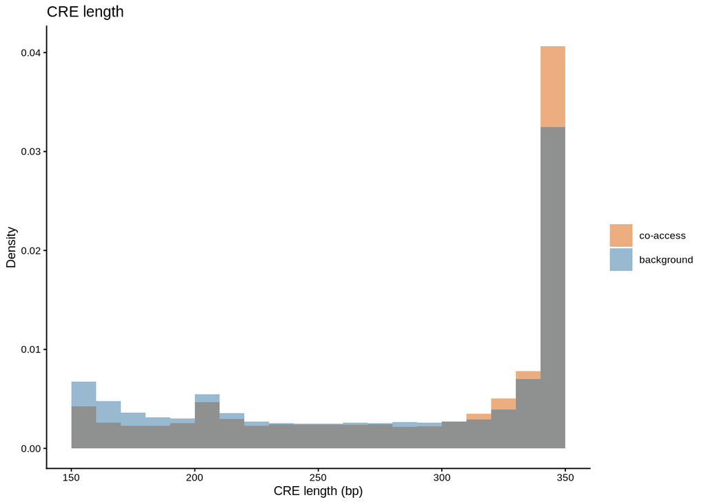

```r
p <- ggplot(cre,aes(length,after_stat(density),fill=set))+
  geom_histogram(binwidth=10,position='identity',alpha=.5,boundary=0)+
  scale_fill_manual(values=set_cols,name=NULL)+
  labs(x='CRE length (bp)',y='Density',title='CRE length')+theme_fiberseq()
save_plot(p,'length_by_set.pdf',7,4.5);print(p)
```

## Which CRE classes tend to be co-access?

The table reports co-access and background counts for each CRE class, the percentage of each class that is co-access, and each class’s percentage of the two sets. The bar plot shows class composition within each set, ordered by the percentage of each class that is co-access.

```r
t3 <- dcast(cre[,.N,by=.(CRE_class,set)],CRE_class~set,value.var='N',fill=0)
setnames(t3,c('co-access','background'),c('n_coaccess','n_background'))
t3[,`:=`(pct_of_class_coaccess=100*n_coaccess/(n_coaccess+n_background),
  pct_of_coaccess_set=100*n_coaccess/sum(n_coaccess),pct_of_background_set=100*n_background/sum(n_background))]
setorder(t3,-pct_of_class_coaccess)
write_tsv(t3,'class_by_set.tsv')
knitr::kable(t3,digits=1)
```

| CRE_class | n_coaccess | n_background | pct_of_class_coaccess | pct_of_coaccess_set | pct_of_background_set |
| --- | --- | --- | --- | --- | --- |
| CA-TF | 21 | 164 | 11.4 | 0.4 | 0.2 |
| TF | 17 | 136 | 11.1 | 0.3 | 0.2 |
| dELS | 2932 | 27423 | 9.7 | 52.8 | 37.8 |
| CA | 21 | 271 | 7.2 | 0.4 | 0.4 |
| CA-H3K4me3 | 36 | 558 | 6.1 | 0.6 | 0.8 |
| pELS | 1701 | 27892 | 5.7 | 30.6 | 38.4 |
| PLS | 794 | 15071 | 5.0 | 14.3 | 20.8 |
| CA-CTCF | 35 | 1067 | 3.2 | 0.6 | 1.5 |

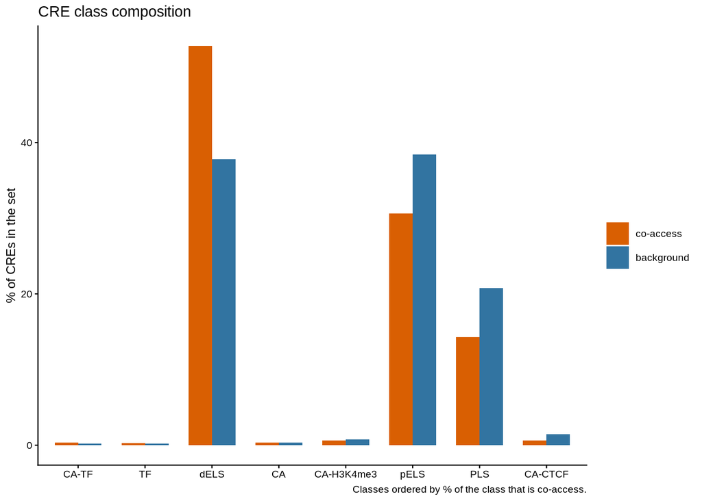

```r
d <- melt(t3[,.(CRE_class,`co-access`=pct_of_coaccess_set,background=pct_of_background_set)],
  id.vars='CRE_class',variable.name='set',value.name='pct')
d[,CRE_class:=factor(CRE_class,levels=t3$CRE_class)]
p <- ggplot(d,aes(CRE_class,pct,fill=set))+geom_col(position='dodge',width=.7)+
  scale_fill_manual(values=set_cols,name=NULL)+
  labs(x=NULL,y='% of CREs in the set',title='CRE class composition',
    caption='Classes ordered by % of the class that is co-access.')+theme_fiberseq()
save_plot(p,'class_by_set.pdf',8,4.5);print(p)
```